# Hello!

### Today:

1. Recap (again!)
2. Finishing `ML_worksheet2.ipynb` Q4-Q7
   - **What** to optimize (the "scoring" param in `cross_validate` and `gridsearch`)
   - How to pick the decision threshold to optimize the model: `TunedThresholdClassifierCV`
   - Doing that within a pipeline
3. Improving your predictions / Optimizing pipelines part 1: `gridsearch` to select numerical "hyperparameters"

## Summary so far of skills

1. Splitting off the holdout sample: If data evolves over time, we... ???
2. Build a pipeline with steps for data preprocessing and an estimation method (`ColumnTransformer` and `pipelines`).
3. ABCD: See what the preprocessor does: `df_after_transform`
4. **Basic** use of that pipeline: `fit`, `predict`, print out accuracy
5. Estimate performance: `cross_validate(pipeline_obj,X_train, y_train)` (and examine output)
6. Estimate performance for many pipeline candidates: `gridsearchCV` (more prac today)

## Classification models

- A **classification model** is when you're predicting an outcome with discrete levels and [is best divided into two parts:](https://scikit-learn.org/stable/modules/classification_threshold.html#)
  1. the statistical problem of learning a model to predict, ideally, class probabilities;
  2. the decision problem to take concrete action based on those probability predictions.
- Our current example:
  1. Step 1: Estimate via logit the probability of a loan charge off based on application data X.
  2. The fitted logit model produces, for a given vector of data X, the predicted probability that y=1 (charge off) for those values of X.
  3. This is not a classification, its a probability, a number in [0,1].
  4. Step 2: A *classification model that uses logit* takes the logit predicted probability, and outputs a prediction: YES, or NO.
- The considerations we learn in this application here apply to many settings: **Predicting what stocks to buy/sell is a two part problem as well**
  1. Estimate $f()$ to model a stock's future return: $ret_{t+1}=f(X_t)$
  2. Apply $f()$ to the latest data to generate predicted returns for all stocks, and then pick which stocks to buy and/or sell.

## Exercises

## Q1

*For these questions, assume your bank uses automated underwriting: If the model says you'll pay back the loan, they make the loan. Make extra (reasonable) assumptions as needed to compare the two models:*

**How much money does M2 save us relative to M1 from reduced charge-offs?**

## Q2

*For these questions, assume your bank uses automated underwriting: If the model says you'll pay back the loan, they make the loan. Make extra (reasonable) assumptions as needed to compare the two models:*

**How much foregone profit does M2 have relative to M1?**

## Q3

*For these questions, assume your bank uses automated underwriting: If the model says you'll pay back the loan, they make the loan. Make extra (reasonable) assumptions as needed to compare the two models:*

**Would you rather use M1 or M2 at your bank and why?**

## Q4

*For these questions, assume your bank uses automated underwriting: If the model says you'll pay back the loan, they make the loan. Make extra (reasonable) assumptions as needed to compare the two models:*

**Write down a profit function for firm. Use the cells of the confusion matrix as variables, as needed.**

- The four cells of the matrix are TN (upper left), FP (upper right), TP (lower right), FN (lower left)

## Q5

*For these questions, assume your bank uses automated underwriting: If the model says you'll pay back the loan, they make the loan. Make extra (reasonable) assumptions as needed to compare the two models:*

**We want to maximize profits. Try to rewrite your profit function to include PRECISION OR RECALL to see if those are monotonically related to profits.**

(Math on next slide)

$$ Profit = (TN*ROA - FN*HaircutRate)*AvgLoanSize $$

Precision: If we multiply profit by $(TN+FN)/(TN+FN)$, we get

$$ = \left(\frac{TN}{(TN+FN)}*ROA - \frac{FN}{(TN+FN)}*H\right)*(AvgLoanSize*(TN+FN)) $$

Renaming things makes this

$$ = \left[Precision_0*ROA - \left(1-Precision_0\right)*H\right]*AvgLoanSize*\#Loans $$

Collecting terms, we have

$$ = \left(Precision_0*(ROA + H) - H\right)*AvgLoanSize*\#Loans $$

As precision goes up, does this?

Not likely! (WHY??)

## Q6: Custom `scoring` functions

So, "What to maximize?" ... what matters!!!

**Let's max profits**. In the worksheet answers, I show how to do this

1. M1 loses $308 times average loan size 😱
2. M2 loses "only" $2 times the average loan size 🫣
3. M3: Change the weights in the logit model. Weight them by the *economic* value of charge off vs value of pay back?
4. Well... how does M3 do??? The surprise is in the worksheet.

Remember: Classification problems have 2 parts:

1. a model predicts class probabilities
2. decide how to turn probability into discrete predictions/actions

What we've done so far does not optimize the second part.

**We should optimize the second step too!!**

## Q7: Pick our **decision rule**/threshold to optimize profits!

*(Go through worksheet 2 answers as prof demo)*

*(results on next slide)*

## By picking the threshold to max profits...

We make money!

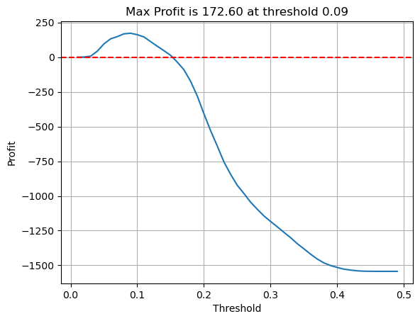

## Ways to pick decision rule/thresholds

1. Manually, as I do above, but: it's best to do via CV
2. CV: `TunedThresholdClassifierCV()` is a CV function that picks thresholds.
3. CV within pipelines: Make `TunedThresholdClassifierCV(<estimator>)` your last step.

## How to optimize hyperparameters

Logit has a "regularization" parameter called "C".

What value should we set for it?

[As the book says,](https://ledatascifi.github.io/ledatascifi-2025/content/05/04f_optimizing_a_model.html#tuning-hyperparameters)

1. Set up your parameter grids: Start with a wide (and sparse) net.
2. Set up `gridsearchCV` and then `.fit()` it.
3. Plot the performance of the models.

Repeat the above steps as needed, adjusting the parameter grids to hone in on best models, until you've found an optimized model.

### Let's try that...

*(To see the code you're about to see, open this lecture file in jupyterlab.)*

I've loaded the LC data. Let's set up the model:

```python
# these weights are equivalent to choosing a thres that maxs profits
clf_logit = make_pipeline(preproc_pipe,
                          LogisticRegression(class_weight={0: 0.02, 1: 0.2}))
```

Now, let's see if the "regularization" parameter in the logit function matters.

Here, I'm going to try a lot of small values, and then some higher values.

```python
parameters =  {'logisticregression__C': list(np.linspace(0.005,.025,20))+list(np.linspace(0.03,.5,15))+list(np.linspace(0.55,2.5,6)) }

grid_search = GridSearchCV(estimator = clf_logit,
                           param_grid = parameters,
                           cv = 5,
                           scoring=prof_score
                           )
```

After fitting the `grid_search`, we examine the performance:

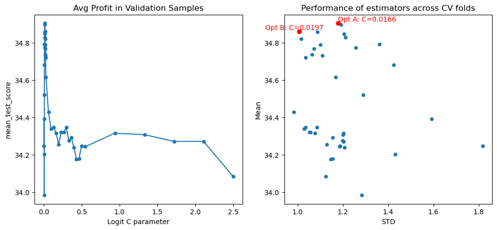

- Do you like A or B more?
- How should we adjust the `parameters` grid?

## Recap

1. We are `scoring` the model on a metric that matters (profit!)
2. We can set the decision rule optimally four ways:
   1. Manually
   2. Via theoretically driven weights
   3. Via a function
   4. Via a function embedded into a pipeline for future improvements
3. Our model is now profitable!
4. We can manipulate a gridsearch
   - to explore a hyperparameter
   - to explore model selection

### Next time on "LendingClub2013"...

Upgrading this model:

- Feature engingeering: More/different X vars?
- Different estimator?